# (How the Trip Duration Differs by Riders' Characteristics and Time)

## by (Mohamed Hossam El_Din)

## Investigation Overview

> In this presentation, I will highlight the features by which a bike trip duration will be affected. These features are ( the day of the week"weekDay", time, user_type, gender, and age)

## Dataset Overview

> This Dataset from February 2019 contains about (183.5 k) record about bike sharing system trips including the duration, start and end times and locations, riders' birth years and genders,and whether they are customers or subscribers. About 10k trips was excluded due to inconsistencies or missing information.

## (Distribution of Trip Durations)

> The distribution of trip durations has a long range of values. After plotting on a log scale, it appears unimodal with it's peak at 6 minutes.

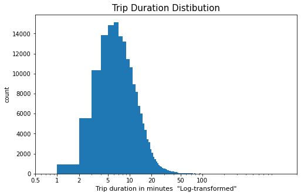

```python
bins = np.arange(0, fordgobike.duration_min.max()+1, 1)
plt.figure(figsize=[8, 5])
plt.hist(data=fordgobike, x='duration_min', bins=bins)
plt.xscale('log')
plt.title('Trip Duration Distibution', fontsize=15)
plt.xlabel('Trip duration in minutes  "Log-transformed"', fontsize=11)
plt.ylabel('count')
ticks = [0.5, 1, 2, 5, 10, 20, 50, 100]
labels = ['{}'.format(v) for v in ticks]
plt.xticks(ticks, labels);
```

## (Day Hours Distibution)

> The distibution is bimodal with two peaks at about (8 am) and (5 pm) which are the times for going to and retuning from a university or work and also the rush hours for traffic where people may use bikes instead of vehicels.

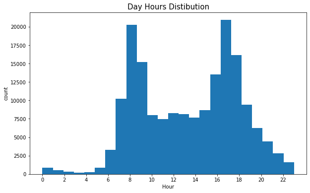

```python
plt.figure(figsize=[10,6])
plt.hist(data=fordgobike, x='start_hour', bins=24)
plt.xticks(np.arange(0,24,2), np.arange(0,24,2))
plt.title('Day Hours Distibution', fontsize=15)
plt.xlabel('Hour')
plt.ylabel('count');
```

## (Trip Duration along Week Days)

> The mean duration is nearly steady, of about 11 minutes, through week days. However, the average duration for weekends is a little bit longer. This was due to the relatively low number of trips on weekedns and the broader duration distribution associated with Saturday and Sunday as appears from the box plot.

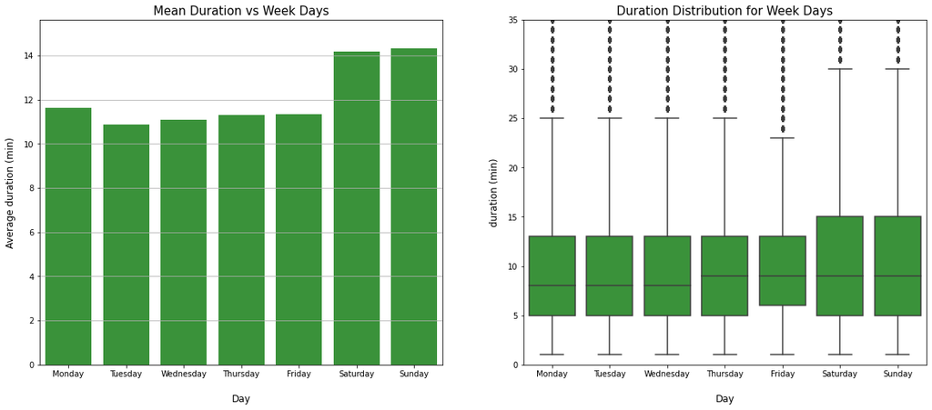

```python
plt.figure(figsize=[20,8])
plt.subplot(1,2,1)
sb.barplot(data=fordgobike, x='weekDay', y='duration_min', color=default_color_2, errwidth=0)
plt.grid(axis='y')
plt.title('Mean Duration vs Week Days', fontsize=15)
plt.xlabel('Day', fontsize=12, labelpad=20)
plt.ylabel('Average duration (min)', fontsize=12, labelpad=10);
plt.subplot(1,2,2)
sb.boxplot(data=fordgobike, x='weekDay', y='duration_min', color=default_color_2)
plt.ylim(0, 35)
plt.title('Duration Distribution for Week Days', fontsize=15)
plt.xlabel('Day', fontsize=12, labelpad=20)
plt.ylabel('duration (min)', fontsize=12, labelpad=10);
```

## (Trip Duration and Age Correlation)

> Despite that most of data is at to lower ages, there is a very weak positive correlation between the age and duration.

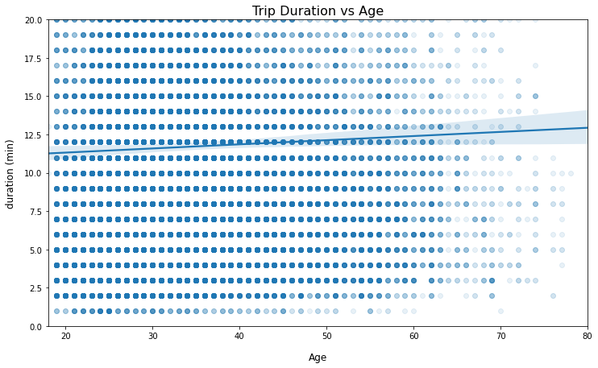

```python
np.random.seed(2019)
samples = np.random.choice(fordgobike.shape[0], 50000, replace = False)
ford_samp = fordgobike.loc[samples,:]
plt.figure(figsize=[12,7])
sb.regplot(data=ford_samp, x='age', y='duration_min', scatter_kws={'alpha':.1})
plt.ylim(0,20)
plt.title('Trip Duration vs Age', fontsize=16)
plt.xlabel('Age', fontsize=12, labelpad=15)
plt.ylabel('duration (min)', fontsize=12, labelpad=10);
```

## (User Type Impact on the Mean Duration along the Week)

> Customers' trips take more time in general. The interesting thing here is the steady average trip time around the week for the Sbscribers versus the vriability in the duration for the Customers. This is actually predictable since subscribers are expected to maintain a fixed use, while customers are free of that commitment.

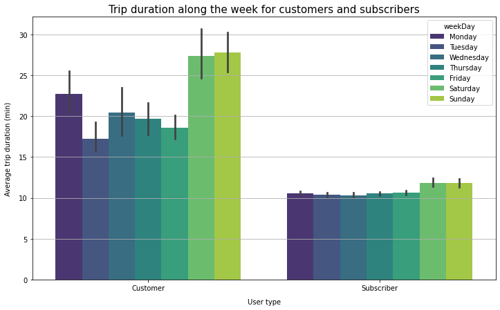

```python
plt.figure(figsize=[12,7])
sb.barplot(data=fordgobike, x='user_type', y='duration_min', hue='weekDay', palette='viridis')
plt.grid(axis='y')
plt.title('Trip duration along the week for customers and subscribers', fontsize= 15)
plt.ylabel('Average trip duration (min)', labelpad=10)
plt.xlabel('User type', labelpad=10);
```

## (Variation of trip duration along the day for customers and subscribers)

> It is surprising that the mean duration is almost steady for the subscribers. One would expect a kind of variation along the day, however, it may be meaningful that it is the case for subscribers, who have trips according to a schedule. For the Customer type, there is variation with 3 peaks, one at (2,3) am, another at noon and afternoon, and one at midnight.

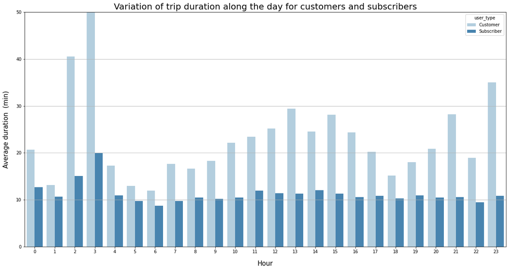

```python
plt.figure(figsize=[20,10])
sb.barplot(data=fordgobike, x='start_hour', y='duration_min', hue='user_type', palette='Blues', ci=0)
plt.grid(axis='y')
plt.ylim(0,50)
plt.title('Variation of trip duration along the day for customers and subscribers', fontsize= 20)
plt.xlabel('Hour', fontsize= 15, labelpad=15)
plt.ylabel('Average duration  (min)', fontsize= 15, labelpad=15);
```

## (Trip duration vs user type for each gender)

> Females generally take longer durations. I don't think that this is related to the physical attributes, but it may be a reflection of gender attitudes, something like the way each gender act or dress. The the distination of each gender probablly has something to do with this.

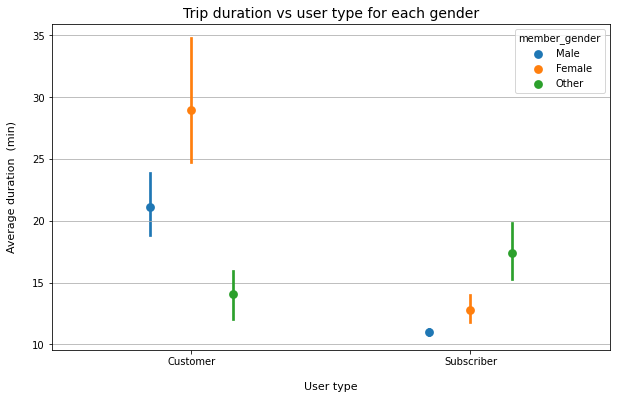

```python
user_order = ['Subscriber', 'Customer']
gender_order = ['Male', 'Female', 'Other']
plt.figure(figsize=[10,6])
sb.pointplot(data=fordgobike.query('age > 25 and age > 45'), x='user_type', y='duration_min', hue='member_gender',
             linestyles="", dodge=.3, hue_order=gender_order)
plt.grid(axis='y')
plt.title('Trip duration vs user type for each gender', fontsize= 14)
plt.xlabel('User type', fontsize= 11, labelpad=15)
plt.ylabel('Average duration  (min)', fontsize= 11, labelpad=15);
```